# Description of Rhone case study

Felipe Mendez-Rios

2025-09-22

# Description of the study case

Several dams have been built to retain water and produce energy from the Rhône River. However, the zones of interest in this study are reaches controlled by friction, where the water surface elevation is influenced not by hydraulic structures but only by friction. Therefore, the reach between Sault-Brénaz (SBR) and Jons (JNS), covering approximately 35 km of streamwise distance, can serve as an example for implementing the methodology. The model of the reach in study was obtained from (Hernandez 2025), observational data to introduce to the model and use into the calibration was obtained from Pella and Capra (n.d.) and Thollet et al. (2024).

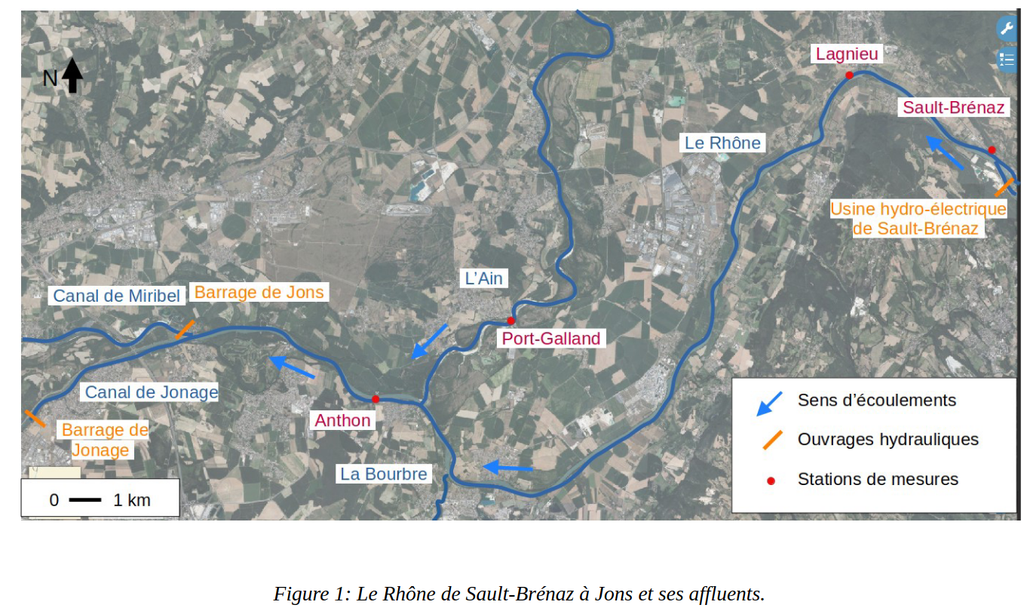

Some data about this zone of study:

- The main channel has two major tributaries: the Bourbre at 36.25 km and the Ain at 34.50 km, both measured from the Jons dam (downstream).
- The annual mean discharge at Jons is approximately 600 m³/s.
- Jons Dam maintains a mostly constant water level over time: 182.4 meters (more details in the table below).
- Retention basin is presented in the Ain tributary
- Five water level measurements were taken at different discharge scenarios on different dates (more details in the Calibration data).
- Several platforms were used to obtain information useful for the model:
  - ([hydroportail](https://hydro.eaufrance.fr/))
  - ([BDOH](https://bdoh.inrae.fr/OBSERVATOIRE-DES-SEDIMENTS-DU-RHONE/))

**Remarks:** If the model starts using LGN data, it should be shortened at the cross-section corresponding to a streamwise distance of 56 km.

Water level at different upstream discharges at Jons

| Upstream.discharge..m3.s. | Water.level..m. |
| --- | --- |
| 86 | 182.60 |
| 1000 | 182.40 |
| 2100 | 182.40 |
| 4500 | 182.25 |

Check the hydrometric stations relevant to modeling the reach under study:

Summary information of the hydrometric stations useful for modelling

[output not shown]

# Modelling experiments

Two experiments is proposed:

- **Case 1:** linear model using three consecutive reaches. The Ain is considered as a punctual apport in the node at Anthon.
- **Case 2:** complet model multi-reach. Taking into account the Ain as tributary and his retension basin.

## Case 1: linear model

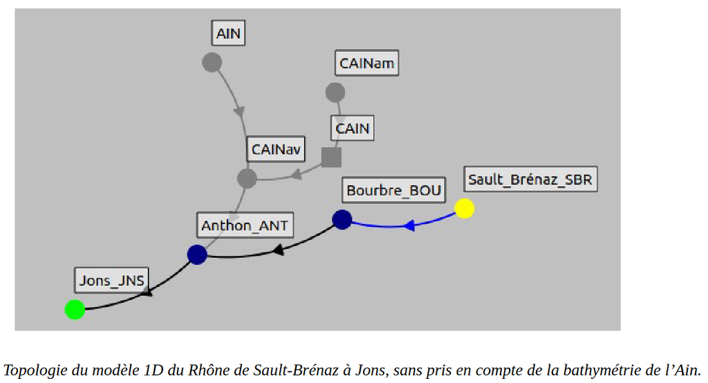

The Ain tributary is modelled as a punctual discharge introduced in the node at Anthon. Series time data is obtained from Port-Galland (4 km upstream), so a temporal lag must be considered. Therefore, for any temporal simulation, it may be more rigorous to perform a simulation with the multi-reach model in order to obtain the discharges just upstream of the confluence with the Rhône. These simulated discharges can then be imposed on the linear model at the Anthon-ANT node.

Just for information, the temporal lag between PGL to ANT is approximately 4 hours for a discharge of 125 m3/s.

## Case 2: complet model

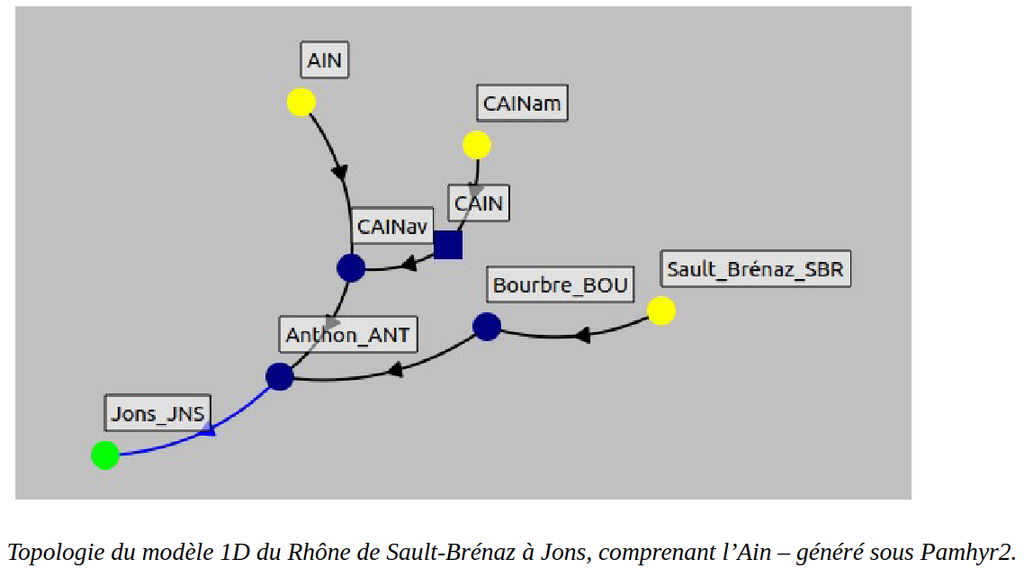

The Ain tributary is modelled as a reach, so a case of multi-reach is considered. Model will start at LGN instead of SBR, so the model is shorten until the KP 55900.

Just for information, the temporal lag between SBR to LGN is approximately 1 hour for a discharge of 400 m3/s.

# Calibration data

Five water surface elevations were measured. The figures below summarizes this information.

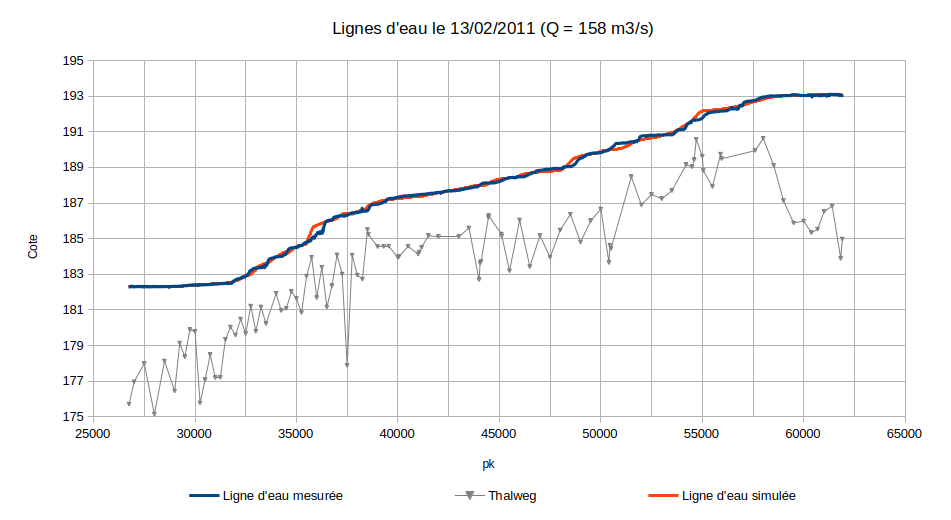

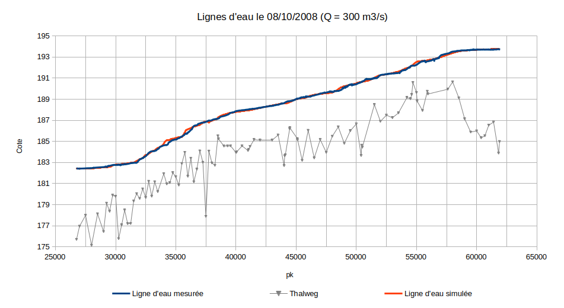

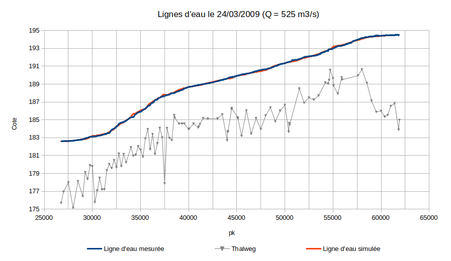

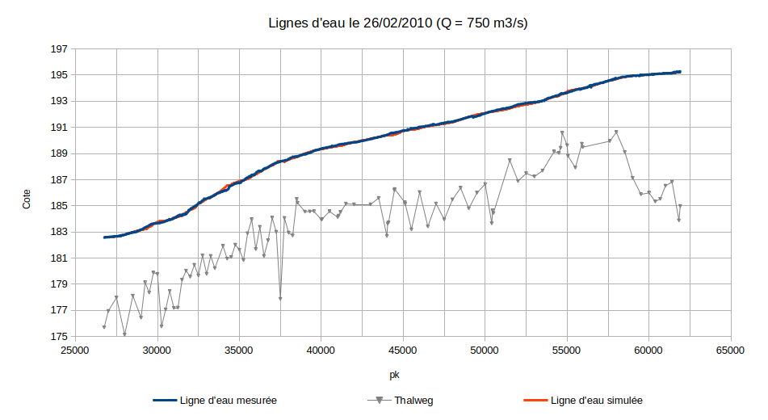

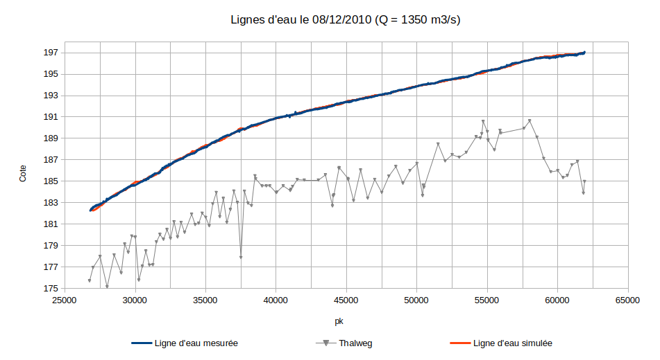

# Boundary conditions:

The table below summarizes whether the input data for the model were available during the period when the water surface elevations were measured. The information needed is:

- Discharge time series (QdT) at LGN
- QdT at TIG-Bourbre
- QdT at PGL-Ain
- ZdT at JNS

Match between input model information and observational data

| Discharge..m3.s. | Date | LGN.QdT | TIG.Bourbre.QdT | PGL.Ain.QdT | JNS.ZdT |
| --- | --- | --- | --- | --- | --- |
| 158 | 13/02/2011 | No | Yes | Yes | 182.4 |
| 300 | 08/10/2008 | No | Yes | Yes | 182.4 |
| 525 | 24/03/2009 | No | Yes | Yes | 182.4 |
| 750 | 26/02/2010 | No | Yes | Yes | 182.4 |
| 1350 | 08/12/2010 | No | Yes | Yes | 182.4 |

**Remarks:**

- **LGN QdT**: the discharge time series is available since 19/11/2020. Stage records are available since 29/02/2000, but no rating curve was reported until 19/11/2020. To overcome this issue, a steady flow condition is assumed during the simulation period around the measurements.
- **JNS ZdT**: the water level is controlled by the opening gate operated by the dam manager. Data reported in the OSR project indicate that the water level remains approximately constant at 182.40 meters. During modeling, the stage time series at Jons will be fixed at this value.

# Bibliography:

Hernandez, Dorian. 2025. “Modèle Du Rhône de Sault-Brénaz à Jons.”

Pella, Hervé, and Hervé Capra. n.d. “Calage_sault_brénaz_jons.”

Thollet, Fabien, Chloé Le Bescond, Mickaël Lagouy, Alexandra Gruat, Ghislaine Grisot, Jérôme Le Coz, Marina Coquery, et al. 2024. “Observatoire des Sédiments du Rhône.” Recherche Data Gouv. https://doi.org/10.17180/OBS.OSR.